# My visual data story

An analysis of short form video content

## Short form content

Short form content and the platforms that host them have grown rampant over the past couple of years, becoming a point of contention and discussion surrounding the youth, attention spans, and the future of digital content.

## A lowering attention span

Attention spans globally are dropping, there are many contributing factors to this, but the frantic rise of short form content tend to be one of the foremost factors.

As short form content allows for more content to be viewed much more rapidly, a terrible loop of new content at the swipe of a finger has taken a rise.

## The various shortform platforms, and their average lengths of videos

The plot below showcases the length of these short form videos by the platform they are from. It shows a clear pattern on some platforms favouring shorter content, like Instagram Reels, while a platform like Youtube Shorts, tends to favour longer content.

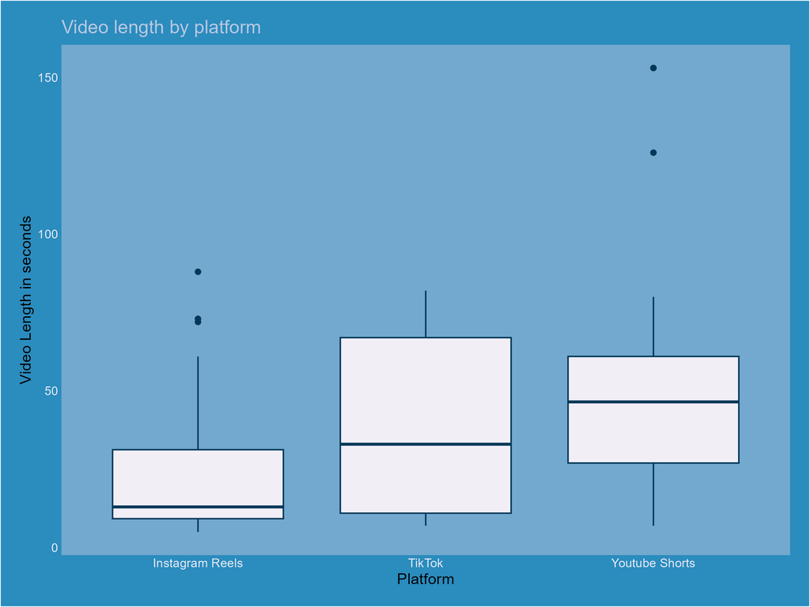

A box plot titled “Video length by platform”, the x-axis is “Platform” with the groups being Instagram Reels, TikTok, and youtube shorts. The y-axis measures the video length by seconds, most platforms tend to have an average video lenght of 15 seconds to 50 seconds

## A changing landscape

It is known that these platforms main goal is to capture the user’s attention and create a digital identity of them and what they enjoy to see, this of course is all done by algorithms, algorithms which change as the what the viewer’s interests change.

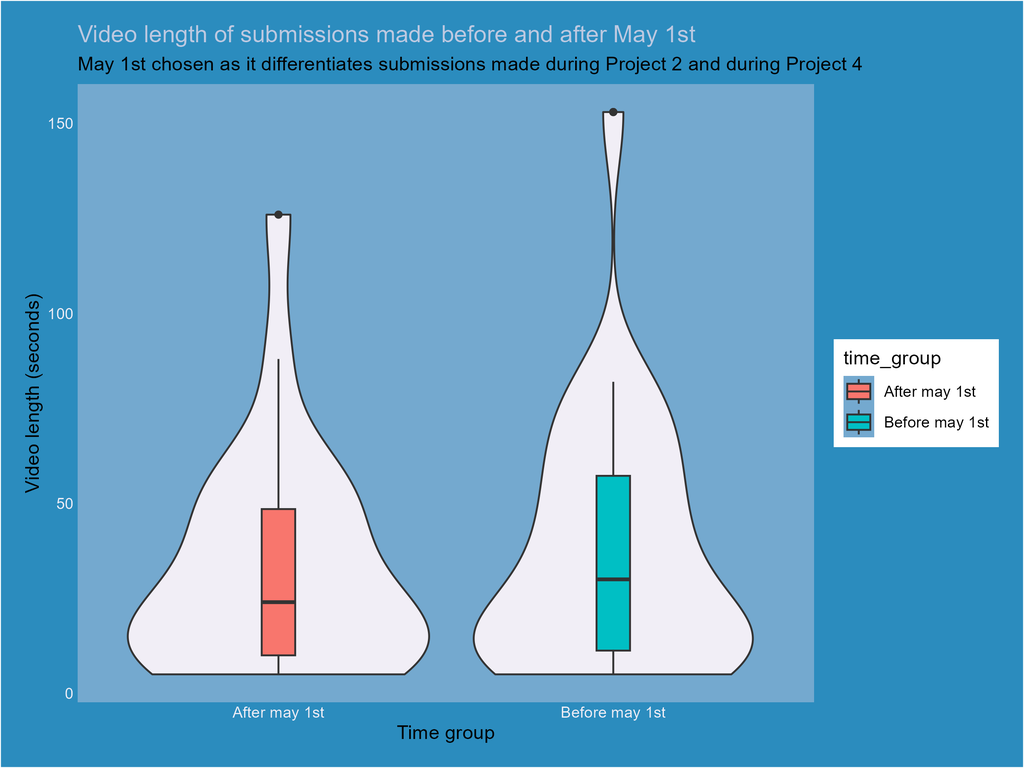

A violin plot showcasing the relationship between video length in second and if asubmission was made before or after may 1st. both groups have a similar mean of about 20-30 seconds long.

## Hashtags

Hashtags act as a way somewhat reasonable to determine the content of the video, if I had many, many more entries I would be able to analyse the actual hashtags rather than just the number of characters, so this serves more as a proof of concept. The number of character in a hashtag is still somewhat important as a longer hashtag might mean that the video is more complicated and has a more specific target audience, another metric to determine this would be the number of views or likes of a video.

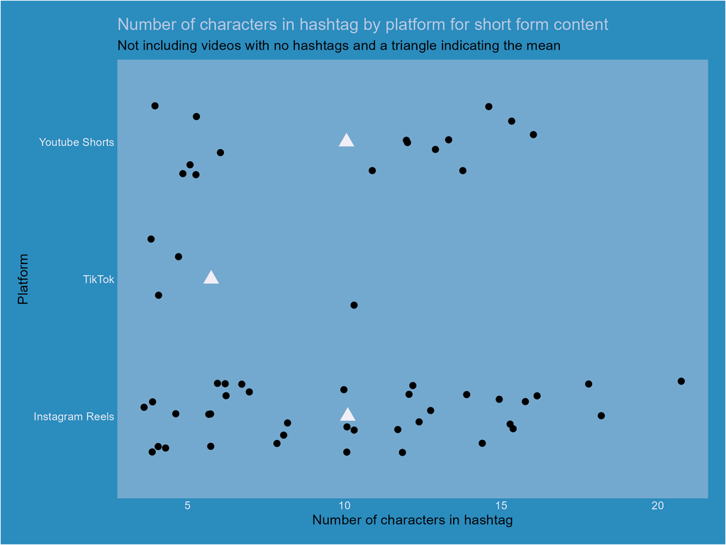

a jitter plot showcasing the relationship between the number of character in the first first hash tags for all of the previously mentioned platforms.

In conclusion I really wish to explore this idea more, as this sort of stuff is very important in the current landscape of the digital world and the physical world at large, it also is one of the biggest factors that could lead to the deintellectualization of the future generations.